# N5 Prelim Revision Booklet - Web Version

## Expanding Brackets

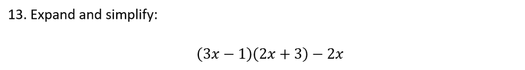

Take care with *negatives* when expanding brackets.

$6x^2+5x-3$

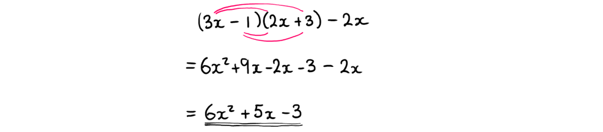

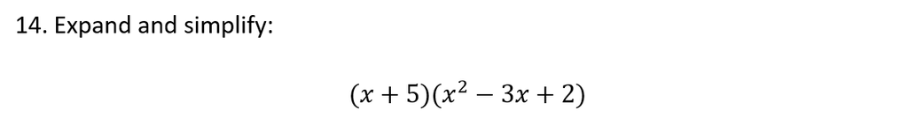

Check the *six terms* obtained from expanding these brackets are correct carefully before you collect like terms.

$x^3+2x^2-13x+10$

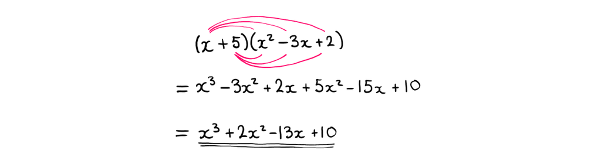

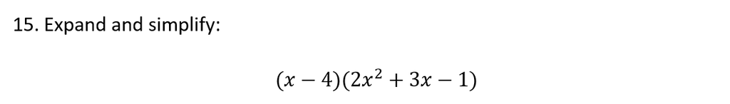

Take care with *multiplying a negative by a negative*.

$2x^3-5x^2-13x+4$

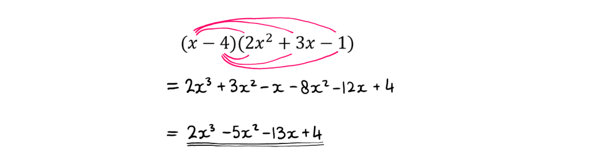

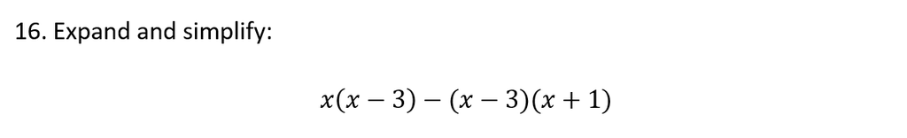

Tackle the expansion of $(x-3)(x+1)$ then consider the "$-$" that lies in front of it.

$-x+3$

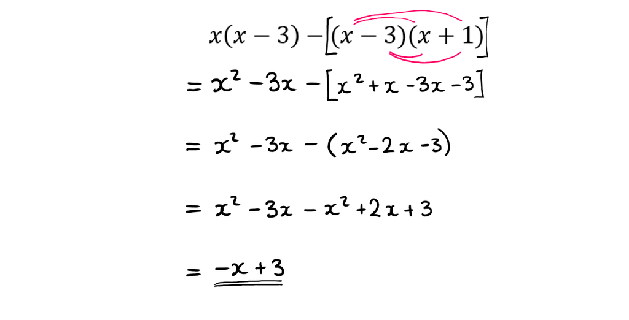

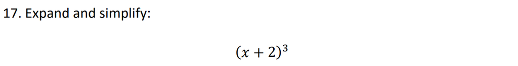

$(x+2)^3$ can be written as $(x+2)(x+2)(x+2)$.

$x^3+6x^2+12x+8$

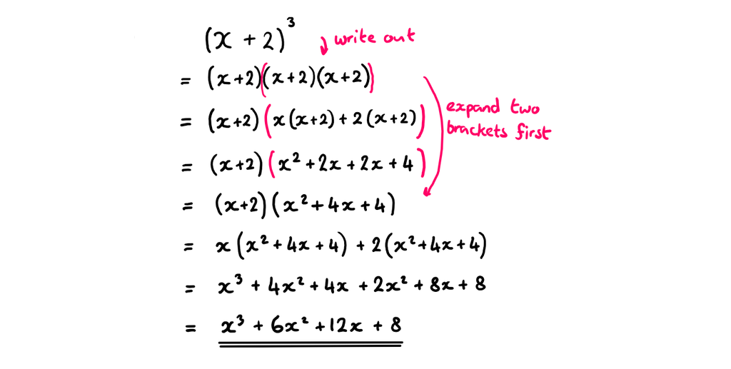

## Similar Shapes

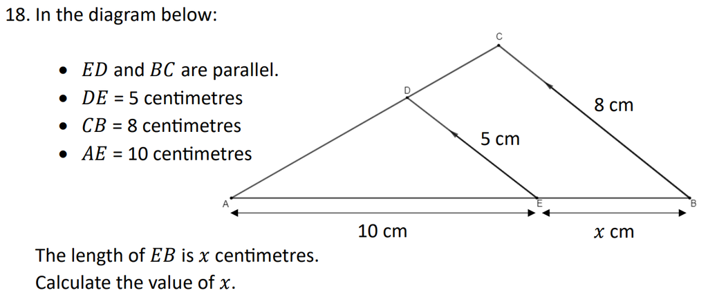

Draw the *two triangles separately*.

$x=6$

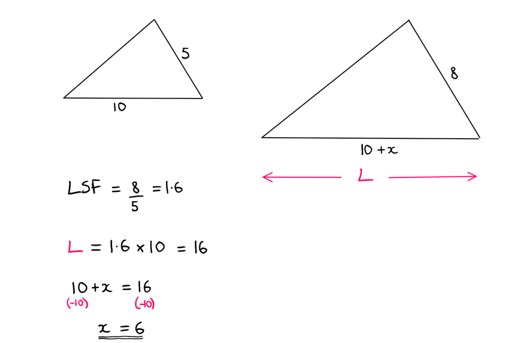

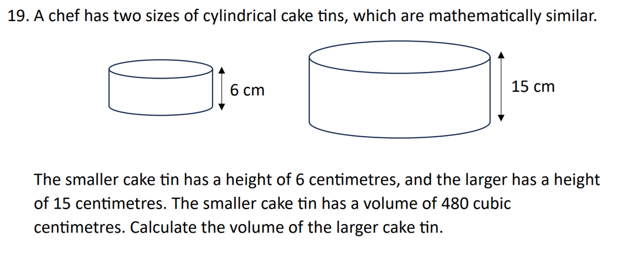

Obtain the LSF *first*, and then think about which scale factor is *needed*.

$7500\text{ cm}^3$

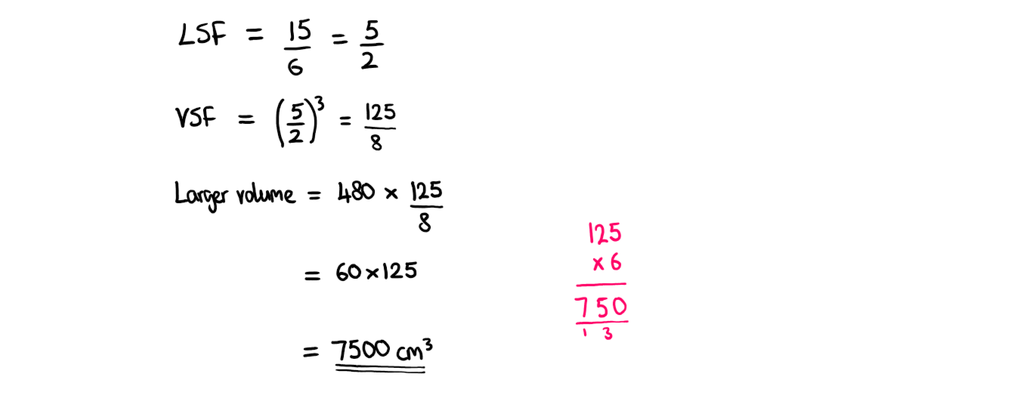

[figure not shown]

Since cost is proportional to area, the **area scale factor** is needed. First, find the *length scale factor*.

£14.40

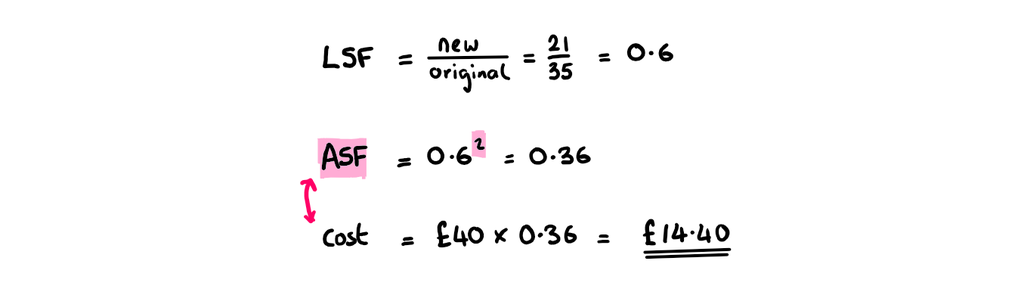

## Percentages

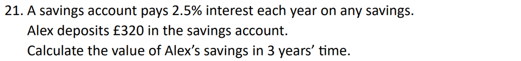

*"100% + 2.5%"*

$£344.61$

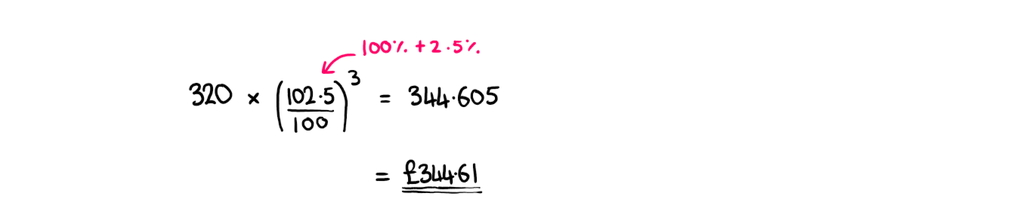

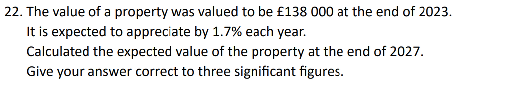

*"100% + 1.7%"*

$£148,000$

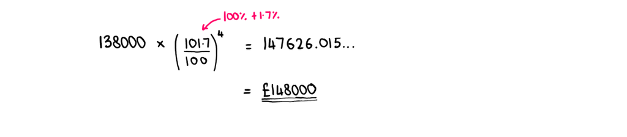

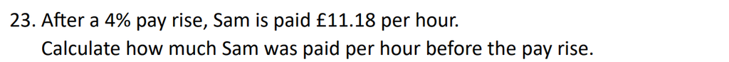

What percentage *of their original pay* is £11.18?

$£10.75$

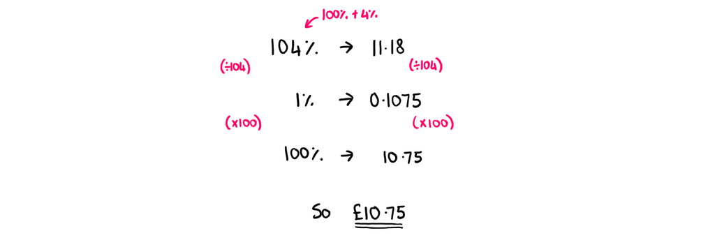

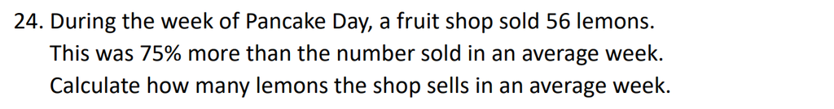

Without a calculator, finding 1% will be awkward. What *other percentage* could be reached, which would let you then find 100% quickly?

$32$

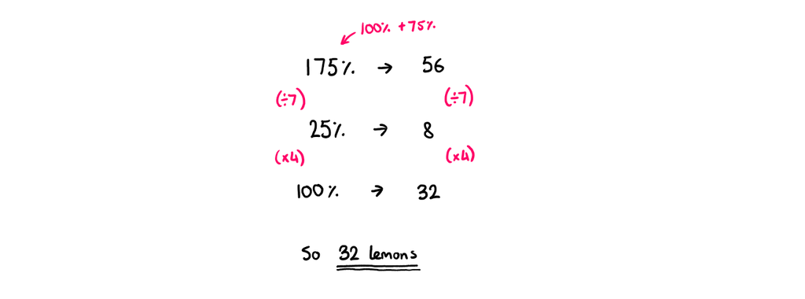

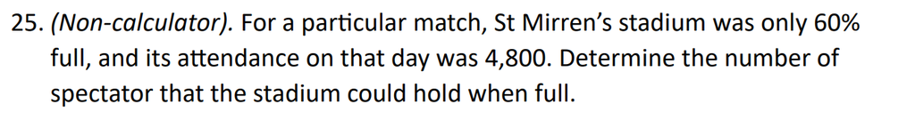

It can be tempting to assume you need to *add* or *subtract* 60% **from 100%**. But that it not needed here: 4800 corresponds to 60% of the total number of spectators when full.

8,000

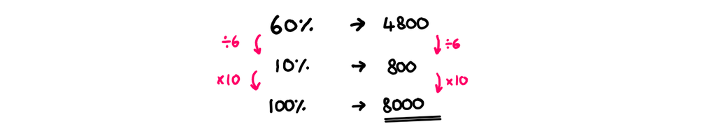

## Numerical Fractions

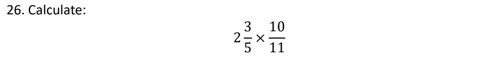

When multiplying (or dividing) factions, the denominators *don't need to be the same*. However, you don't want either to be a *mixed fraction*.

$\dfrac{26}{11}$ or $2\dfrac{4}{11}$

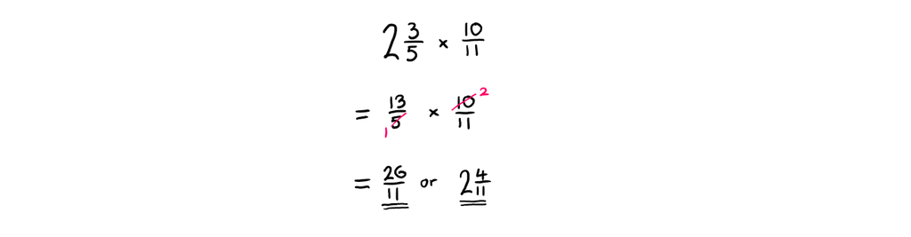

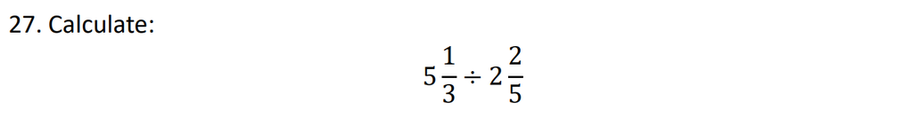

How can a division by a fraction be rewritten as a *multiplication*?

$\dfrac{20}{9}$ or $2\dfrac{2}{9}$

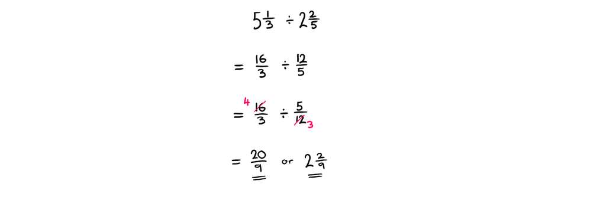

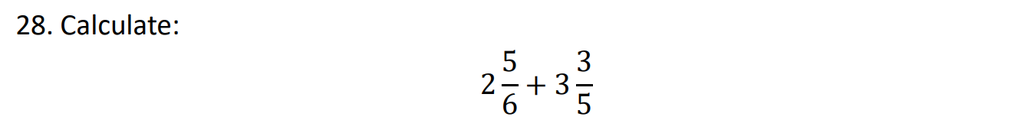

When adding (or subtracting) fractions, the *denominators need to be equal*.

$\dfrac{193}{30}$ or $6\dfrac{13}{30}$

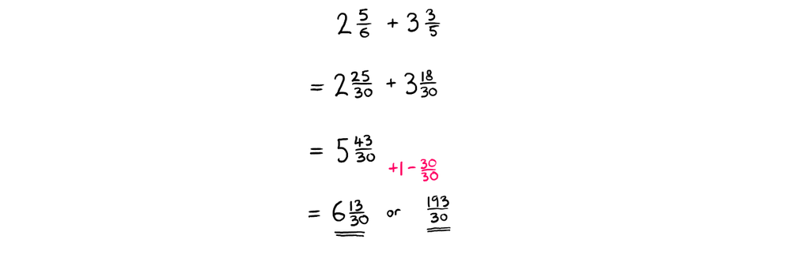

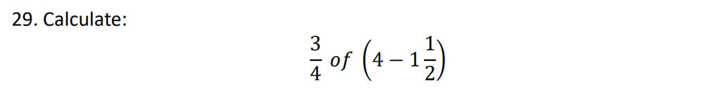

"$\dfrac{3}{4}$ *of...*" is the same as "$\dfrac{3}{4}\times$..."

$\dfrac{15}{8}$ or $1\dfrac{7}{8}$

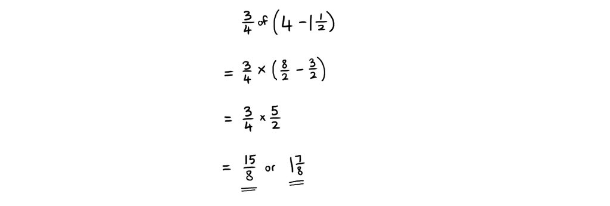

## Pythagoras

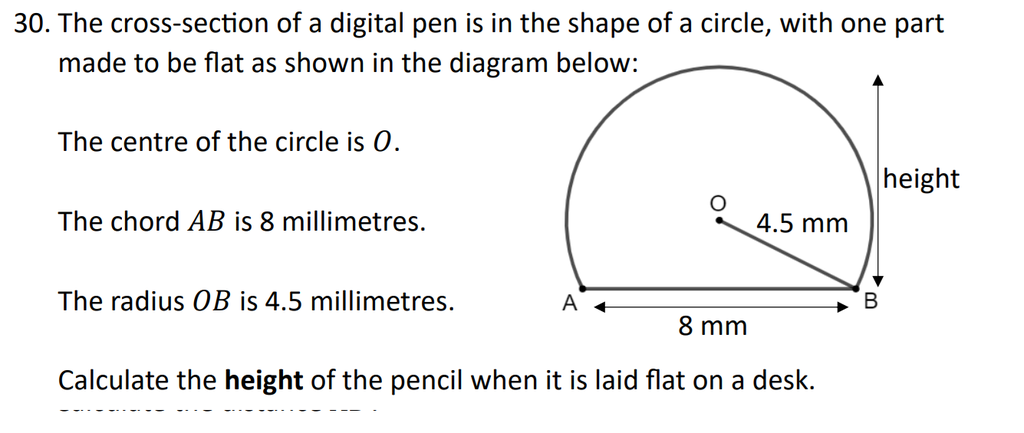

Isolate a *right-angled triangle* within the diagram to focus on.

$6.56\text{ mm}$

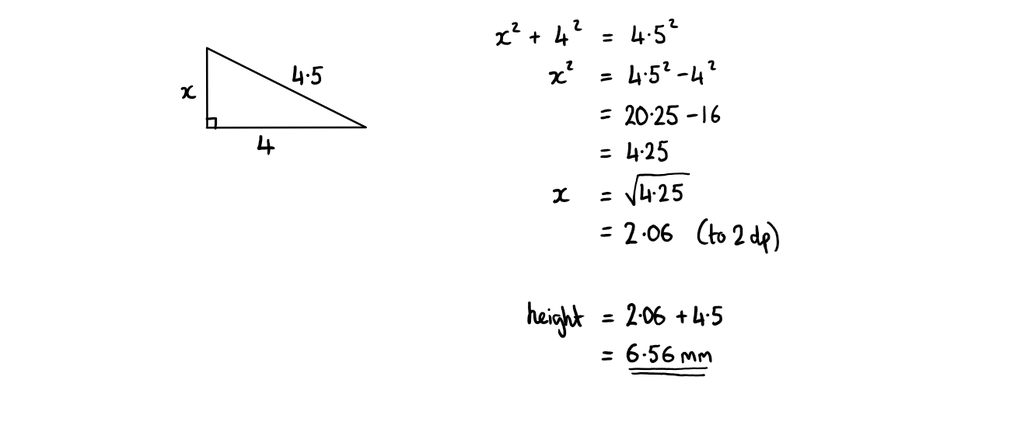

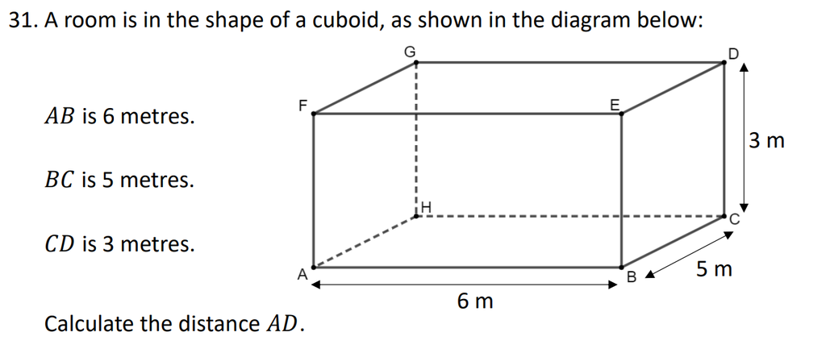

Start by calculating the length of line *AC*, which lies *beneath* line AD.

$8.37\text{ m}$

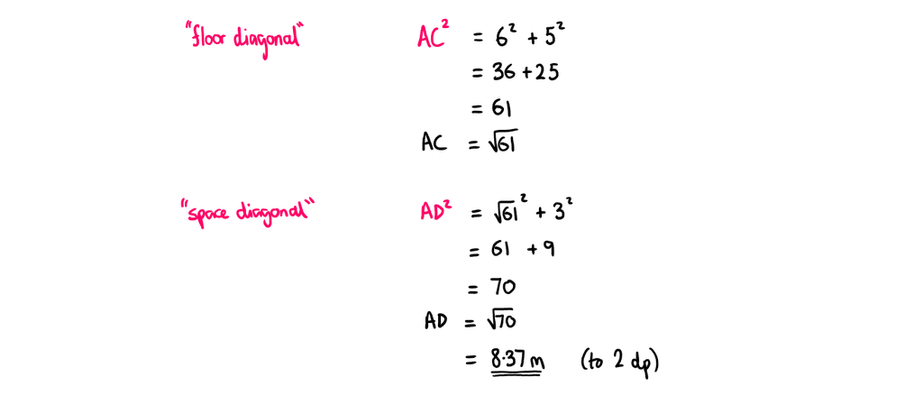

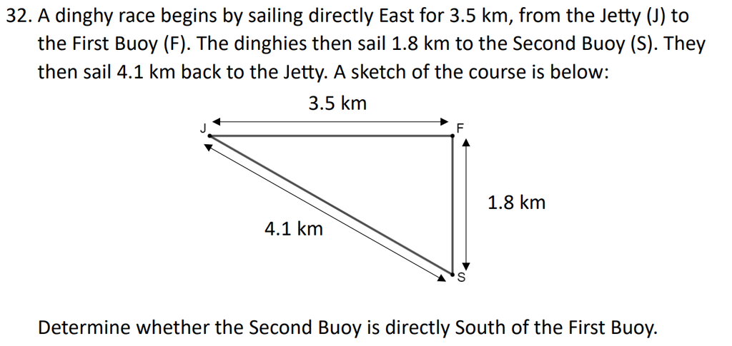

Since line JF lies East-West, the question is asking whether line FS makes a *right-angle* with JF.

No, the Second Buoy is not directly South of the First Buoy (with justification).

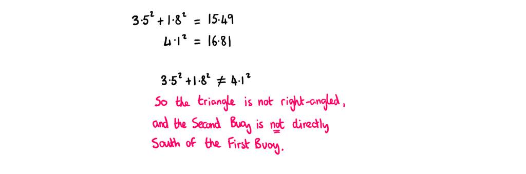

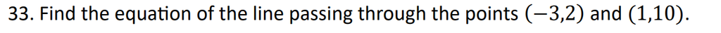

Start by using a formula to find the *gradient* between the points.

$y=2x+8$

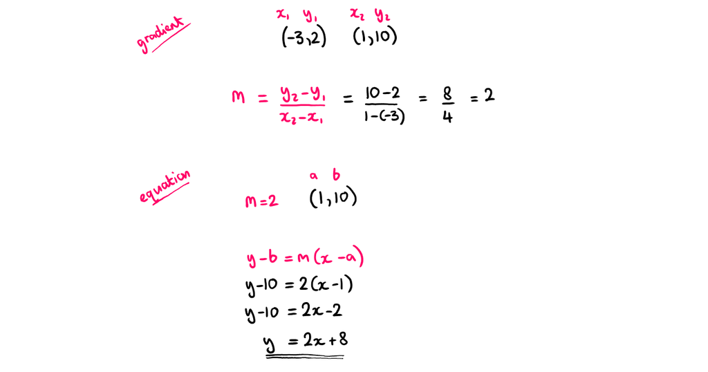

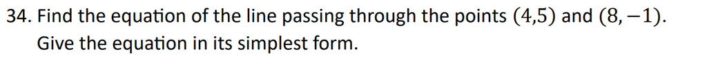

Start by using a formula to find the *gradient* between the points.

$y=-\frac{3}{2}x+11$ or $2y=-3x+22$

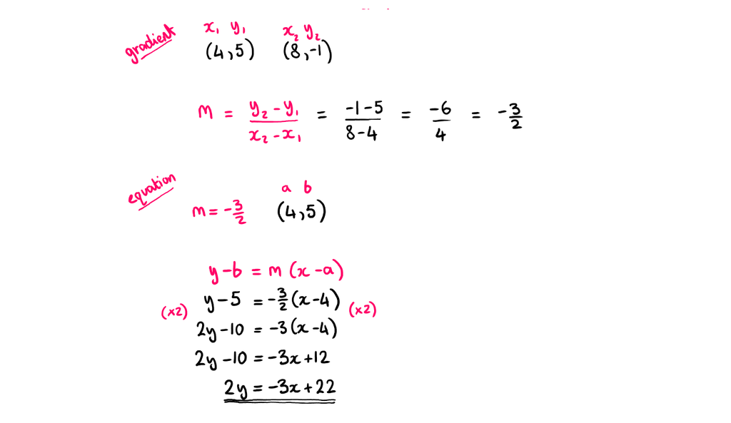

## Straight Lines

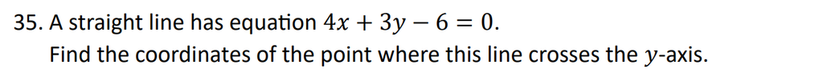

First rearrange the equation to make $y$ the subject: $y=\dots$

$(0,2)$

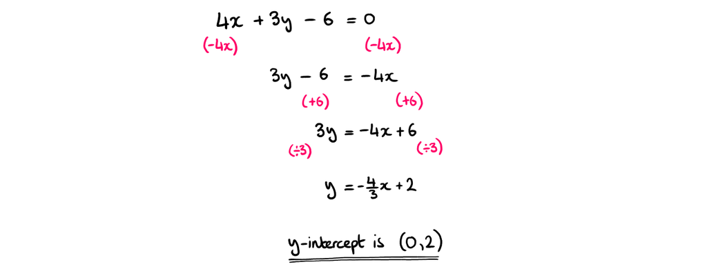

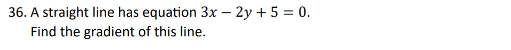

First rearrange the equation to make $y$ the subject: $y=\dots$

$m=\frac{3}{2}$

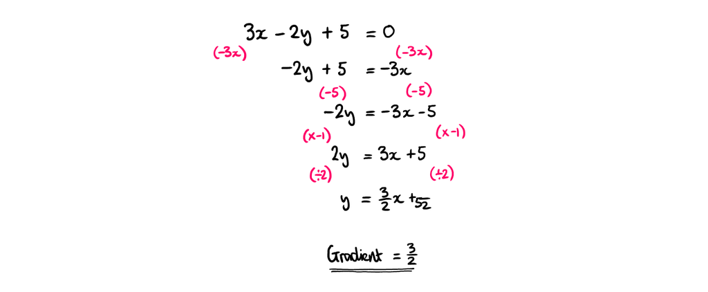

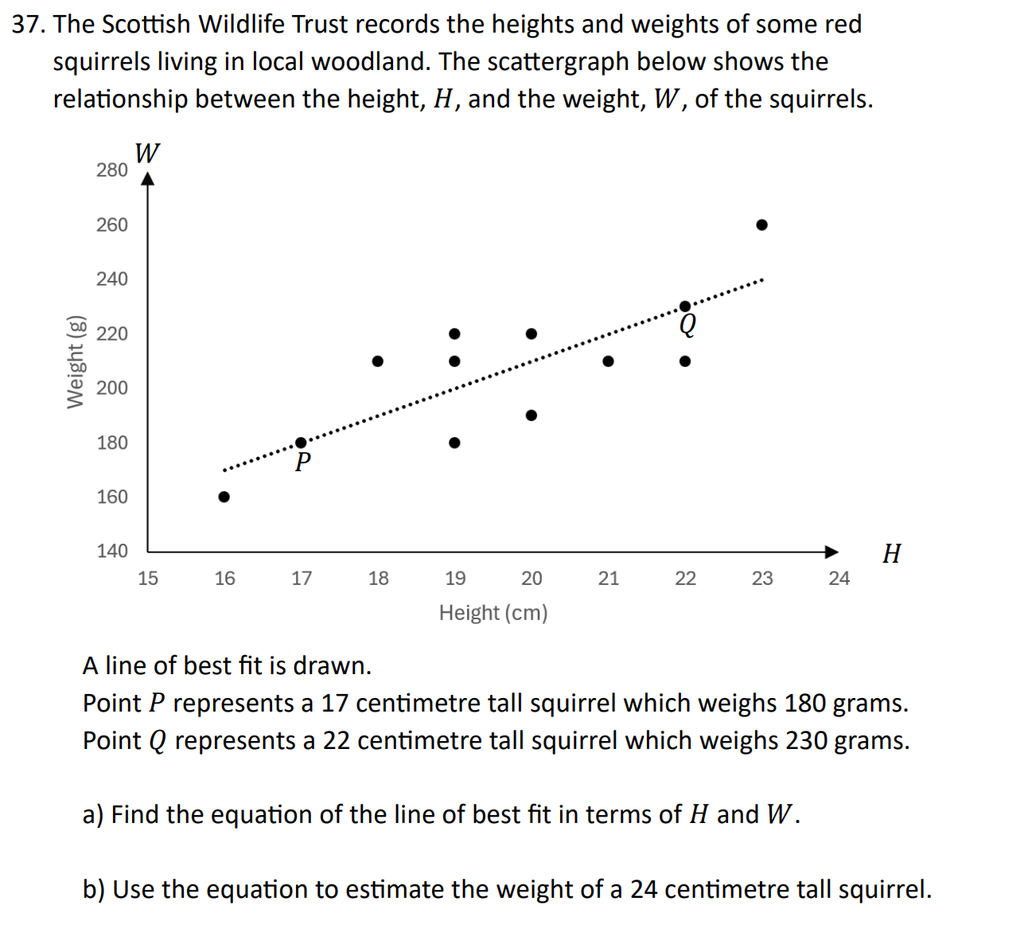

Start by finding two data points which lie *directly on the line of best fit*, and write down their coordinates.

Equation: $W=10H+10$

Weight: $250\text{ grams}$

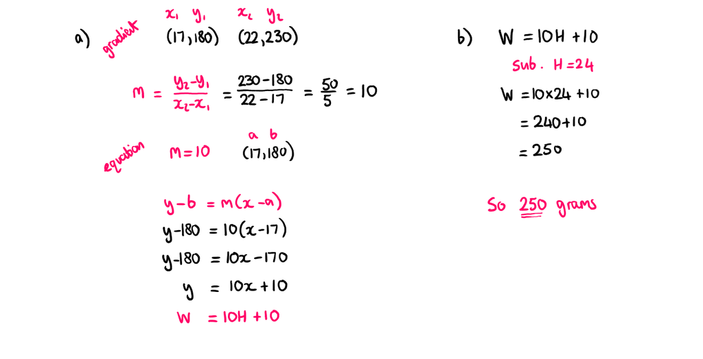

## Functions

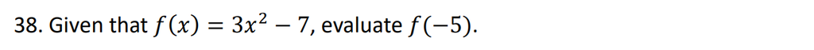

Use brackets when *substituting* values into functions.

$68$

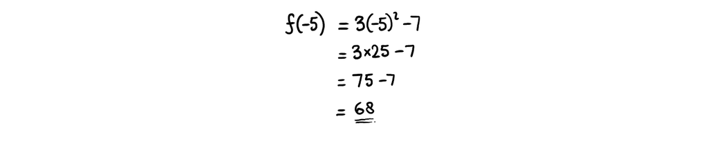

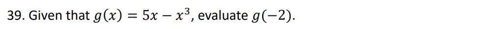

Take care with *negatives*.

$-2$

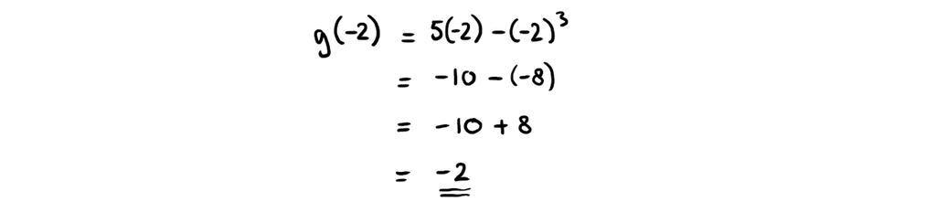

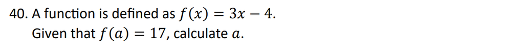

The questions is *not* asking for 17 to be substituted *into* the function in place of $x$.

$a=7$

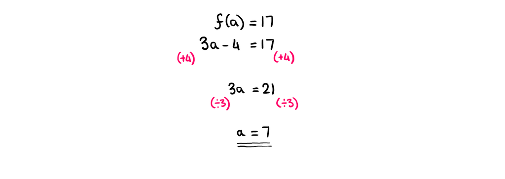

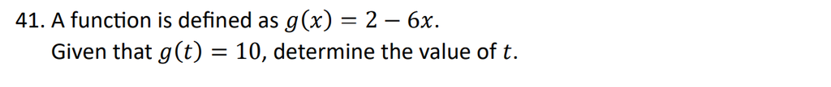

You can always *check* your answer for $t$ is correct by substituting into *into* the function afterwards.

$t=-\frac{4}{3}$

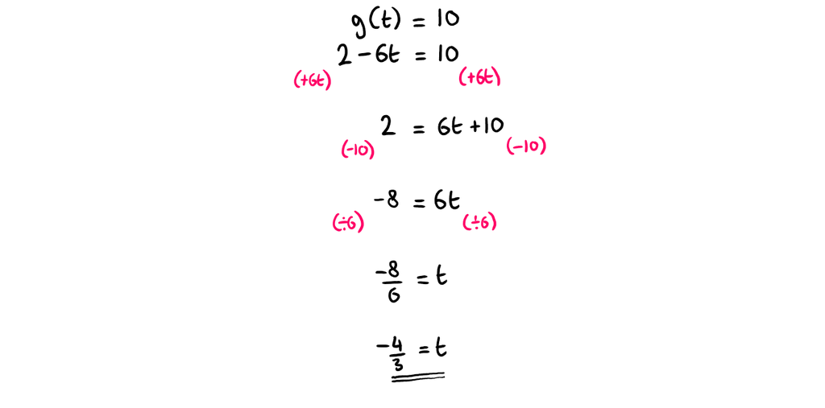